# Expansión de la CASEN sobre el CENSO (Región 11)

De ingresos sobre una categoría de respuesta

VE-CC-AJ

DataIntelligence

Jueves 24-06-2021

Abstract

Expandiremos los ingresos promedios comunales obtenidos de la CASEN sobre la categoría de respuesta: “tejas o tejuelas de arcilla, metálicas, de cemento, de madera, asfálticas o plásticas” del campo P03B del CENSO de viviendas, que fue la categoría de respuesta que más alto correlaciona con los ingresos expandidos (obtenidos de la multiplicación del ingreso promedio y los habitantes), ambos a nivel comunal.

Haremos el análisis sobre la región 11.

Ensayaremos diferentes modelos dentro del análisis de regresión cuya variable independiente será: “frecuencia de población que posee la variable Censal respecto a la zona” y la dependiente: “ingreso expandido por zona”

Lo anterior para elegir el que posea el mayor coeficiente de determinación y así contruir una tabla de valores predichos.

## 1 Variable CENSO

Necesitamos calcular las frecuencias a nivel censal de las respuestas correspondientes a la categoría: “tejas o tejuelas de arcilla, metálicas, de cemento, de madera, asfálticas o plásticas” del campo **P03B** del Censo de viviendas. Recordemos que ésta fué la más alta correlación en relación a los ingresos expandidos [(ver punto 1.2 aquí)](https://rpubs.com/dataintelligence/corr_004_viviendas).

### 1.1 Lectura y filtrado de la tabla censal de viviendas

Leemos la tabla Casen 2017 de viviendas que ya tiene integrada la clave zonal:

```r
tabla_con_clave <- readRDS("censo_viviendas_con_clave_17.rds")
r3_100 <- tabla_con_clave[c(1:100),]
kbl(r3_100) %>%
  kable_styling(bootstrap_options = c("striped", "hover")) %>%
  kable_paper() %>%
  scroll_box(width = "100%", height = "300px")
```

| REGION | PROVINCIA | COMUNA | DC | AREA | ZC_LOC | ID_ZONA_LOC | NVIV | P01 | P02 | P03A | P03B | P03C | P04 | P05 | CANT_HOG | CANT_PER | REGION_15R | PROVINCIA_15R | COMUNA_15R | clave |
| --- | --- | --- | --- | --- | --- | --- | --- | --- | --- | --- | --- | --- | --- | --- | --- | --- | --- | --- | --- | --- |
| 15 | 152 | 15202 | 1 | 2 | 6 | 13225 | 1 | 3 | 1 | 5 | 3 | 5 | 1 | 4 | 1 | 1 | 15 | 152 | 15202 | 15202012006 |
| 15 | 152 | 15202 | 1 | 2 | 6 | 13225 | 2 | 1 | 3 | 98 | 98 | 98 | 98 | 98 | 0 | 0 | 15 | 152 | 15202 | 15202012006 |
| 15 | 152 | 15202 | 1 | 2 | 6 | 13225 | 3 | 1 | 1 | 5 | 3 | 5 | 2 | 3 | 1 | 4 | 15 | 152 | 15202 | 15202012006 |
| 15 | 152 | 15202 | 1 | 2 | 6 | 13225 | 4 | 1 | 4 | 98 | 98 | 98 | 98 | 98 | 0 | 0 | 15 | 152 | 15202 | 15202012006 |
| 15 | 152 | 15202 | 1 | 2 | 6 | 13225 | 5 | 3 | 4 | 98 | 98 | 98 | 98 | 98 | 0 | 0 | 15 | 152 | 15202 | 15202012006 |
| 15 | 152 | 15202 | 1 | 2 | 6 | 13225 | 6 | 3 | 4 | 98 | 98 | 98 | 98 | 98 | 0 | 0 | 15 | 152 | 15202 | 15202012006 |
| 15 | 152 | 15202 | 1 | 2 | 6 | 13225 | 7 | 3 | 4 | 98 | 98 | 98 | 98 | 98 | 0 | 0 | 15 | 152 | 15202 | 15202012006 |
| 15 | 152 | 15202 | 1 | 2 | 6 | 13225 | 8 | 3 | 3 | 98 | 98 | 98 | 98 | 98 | 0 | 0 | 15 | 152 | 15202 | 15202012006 |
| 15 | 152 | 15202 | 1 | 2 | 6 | 13225 | 9 | 3 | 1 | 5 | 3 | 5 | 1 | 4 | 1 | 4 | 15 | 152 | 15202 | 15202012006 |
| 15 | 152 | 15202 | 1 | 2 | 6 | 13225 | 10 | 1 | 1 | 5 | 3 | 4 | 1 | 4 | 1 | 1 | 15 | 152 | 15202 | 15202012006 |
| 15 | 152 | 15202 | 1 | 2 | 6 | 13225 | 11 | 1 | 2 | 98 | 98 | 98 | 98 | 98 | 0 | 0 | 15 | 152 | 15202 | 15202012006 |
| 15 | 152 | 15202 | 1 | 2 | 6 | 13225 | 12 | 1 | 4 | 98 | 98 | 98 | 98 | 98 | 0 | 0 | 15 | 152 | 15202 | 15202012006 |
| 15 | 152 | 15202 | 1 | 2 | 6 | 13225 | 13 | 1 | 1 | 5 | 3 | 4 | 1 | 4 | 1 | 3 | 15 | 152 | 15202 | 15202012006 |
| 15 | 152 | 15202 | 1 | 2 | 6 | 13225 | 14 | 1 | 3 | 98 | 98 | 98 | 98 | 98 | 0 | 0 | 15 | 152 | 15202 | 15202012006 |
| 15 | 152 | 15202 | 1 | 2 | 6 | 13225 | 15 | 1 | 4 | 98 | 98 | 98 | 98 | 98 | 0 | 0 | 15 | 152 | 15202 | 15202012006 |
| 15 | 152 | 15202 | 1 | 2 | 6 | 13225 | 16 | 1 | 1 | 5 | 3 | 5 | 1 | 3 | 1 | 3 | 15 | 152 | 15202 | 15202012006 |
| 15 | 152 | 15202 | 1 | 2 | 6 | 13225 | 17 | 1 | 1 | 5 | 3 | 5 | 2 | 4 | 1 | 8 | 15 | 152 | 15202 | 15202012006 |
| 15 | 152 | 15202 | 1 | 2 | 6 | 13225 | 18 | 3 | 1 | 5 | 3 | 5 | 1 | 1 | 1 | 1 | 15 | 152 | 15202 | 15202012006 |
| 15 | 152 | 15202 | 1 | 2 | 6 | 13225 | 19 | 3 | 1 | 5 | 3 | 5 | 1 | 3 | 1 | 1 | 15 | 152 | 15202 | 15202012006 |
| 15 | 152 | 15202 | 1 | 2 | 6 | 13225 | 20 | 1 | 1 | 5 | 3 | 5 | 2 | 1 | 1 | 2 | 15 | 152 | 15202 | 15202012006 |
| 15 | 152 | 15202 | 1 | 2 | 6 | 13225 | 21 | 1 | 4 | 98 | 98 | 98 | 98 | 98 | 0 | 0 | 15 | 152 | 15202 | 15202012006 |
| 15 | 152 | 15202 | 1 | 2 | 6 | 13225 | 22 | 1 | 4 | 98 | 98 | 98 | 98 | 98 | 0 | 0 | 15 | 152 | 15202 | 15202012006 |
| 15 | 152 | 15202 | 1 | 2 | 6 | 13225 | 23 | 3 | 4 | 98 | 98 | 98 | 98 | 98 | 0 | 0 | 15 | 152 | 15202 | 15202012006 |
| 15 | 152 | 15202 | 1 | 2 | 6 | 13225 | 24 | 1 | 3 | 98 | 98 | 98 | 98 | 98 | 0 | 0 | 15 | 152 | 15202 | 15202012006 |
| 15 | 152 | 15202 | 1 | 2 | 6 | 13225 | 25 | 1 | 1 | 5 | 3 | 5 | 1 | 4 | 1 | 2 | 15 | 152 | 15202 | 15202012006 |
| 15 | 152 | 15202 | 1 | 2 | 6 | 13225 | 26 | 1 | 4 | 98 | 98 | 98 | 98 | 98 | 0 | 0 | 15 | 152 | 15202 | 15202012006 |
| 15 | 152 | 15202 | 1 | 2 | 6 | 13225 | 27 | 3 | 4 | 98 | 98 | 98 | 98 | 98 | 0 | 0 | 15 | 152 | 15202 | 15202012006 |
| 15 | 152 | 15202 | 1 | 2 | 6 | 13225 | 28 | 3 | 1 | 5 | 3 | 5 | 1 | 4 | 1 | 5 | 15 | 152 | 15202 | 15202012006 |
| 15 | 152 | 15202 | 1 | 2 | 6 | 13225 | 29 | 1 | 4 | 98 | 98 | 98 | 98 | 98 | 0 | 0 | 15 | 152 | 15202 | 15202012006 |
| 15 | 152 | 15202 | 1 | 2 | 6 | 13225 | 30 | 3 | 4 | 98 | 98 | 98 | 98 | 98 | 0 | 0 | 15 | 152 | 15202 | 15202012006 |

[output cut: 70 more lines]

Despleguemos los códigos de regiones de nuestra tabla:

```r
regiones <- unique(tabla_con_clave$REGION)
regiones
```

```
##  [1] 15 14 13 12 11 10  9 16  8  7  6  5  4  3  2  1
```

```r
tabla_con_clave <- filter(tabla_con_clave, tabla_con_clave$REGION == 11)
```

### 1.2 Cálculo de frecuencias

```r
tabla_con_clave_f <- tabla_con_clave[,-c(1,2,4,5,6,7,8,9,10,11,13,14,15,16,17,18,19,20),drop=FALSE]
names(tabla_con_clave_f)[2] <- "Tipo de techo"
# Ahora filtramos por Tipo de techo = 1.
tabla_con_clave_ff <- filter(tabla_con_clave_f, tabla_con_clave_f$`Tipo de techo` == 1)
# Determinamos las frecuencias por zona:
b <- tabla_con_clave_ff$clave
c <- tabla_con_clave_ff$`Tipo de techo`
d <- tabla_con_clave_ff$COMUNA
cross_tab =  xtabs( ~ unlist(b) + unlist(c)+ unlist(d))
tabla <- as.data.frame(cross_tab)
d <-tabla[!(tabla$Freq == 0),]
names(d)[1] <- "zona"
d$anio <- "2017"
```

Veamos los primeros 100 registros:

```r
r3_100 <- d[c(1:100),]
kbl(r3_100) %>%
  kable_styling(bootstrap_options = c("striped", "hover")) %>%
  kable_paper() %>%
  scroll_box(width = "100%", height = "300px")
```

|  | zona | unlist.c. | unlist.d. | Freq | anio |
| --- | --- | --- | --- | --- | --- |
| 1 | 11101011001 | 1 | 11101 | 30 | 2017 |
| 2 | 11101011002 | 1 | 11101 | 80 | 2017 |
| 3 | 11101011003 | 1 | 11101 | 20 | 2017 |
| 4 | 11101011004 | 1 | 11101 | 22 | 2017 |
| 5 | 11101011005 | 1 | 11101 | 32 | 2017 |
| 6 | 11101011006 | 1 | 11101 | 93 | 2017 |
| 7 | 11101011007 | 1 | 11101 | 75 | 2017 |
| 8 | 11101022003 | 1 | 11101 | 2 | 2017 |
| 9 | 11101022010 | 1 | 11101 | 2 | 2017 |
| 10 | 11101022031 | 1 | 11101 | 1 | 2017 |
| 11 | 11101022038 | 1 | 11101 | 3 | 2017 |
| 12 | 11101032005 | 1 | 11101 | 1 | 2017 |
| 13 | 11101032032 | 1 | 11101 | 5 | 2017 |
| 14 | 11101032034 | 1 | 11101 | 1 | 2017 |
| 15 | 11101032901 | 1 | 11101 | 2 | 2017 |
| 16 | 11101042022 | 1 | 11101 | 3 | 2017 |
| 17 | 11101042024 | 1 | 11101 | 3 | 2017 |
| 18 | 11101042027 | 1 | 11101 | 6 | 2017 |
| 19 | 11101052004 | 1 | 11101 | 6 | 2017 |
| 20 | 11101052008 | 1 | 11101 | 5 | 2017 |
| 21 | 11101052014 | 1 | 11101 | 6 | 2017 |
| 22 | 11101052901 | 1 | 11101 | 3 | 2017 |
| 23 | 11101062023 | 1 | 11101 | 1 | 2017 |
| 24 | 11101062025 | 1 | 11101 | 2 | 2017 |
| 25 | 11101072014 | 1 | 11101 | 4 | 2017 |
| 26 | 11101072018 | 1 | 11101 | 57 | 2017 |
| 27 | 11101072019 | 1 | 11101 | 7 | 2017 |
| 28 | 11101072020 | 1 | 11101 | 4 | 2017 |
| 29 | 11101072035 | 1 | 11101 | 3 | 2017 |
| 30 | 11101072036 | 1 | 11101 | 8 | 2017 |

[output cut: 70 more lines]

Agregamos un cero a los códigos comunales de cuatro dígitos:

```r
codigos <- d$unlist.d.
rango <- seq(1:nrow(d))
cadena <- paste("0",codigos[rango], sep = "")
cadena <- substr(cadena,(nchar(cadena)[rango])-(4),6)
codigos <- as.data.frame(codigos)
cadena <- as.data.frame(cadena)
comuna_corr <- cbind(d,cadena)
comuna_corr <- comuna_corr[,-c(2,3),drop=FALSE]
names(comuna_corr)[4] <- "código"
r3_100 <- comuna_corr[c(1:100),]
kbl(r3_100) %>%
  kable_styling(bootstrap_options = c("striped", "hover")) %>%
  kable_paper() %>%
  scroll_box(width = "100%", height = "300px")
```

|  | zona | Freq | anio | código |
| --- | --- | --- | --- | --- |
| 1 | 11101011001 | 30 | 2017 | 11101 |
| 2 | 11101011002 | 80 | 2017 | 11101 |
| 3 | 11101011003 | 20 | 2017 | 11101 |
| 4 | 11101011004 | 22 | 2017 | 11101 |
| 5 | 11101011005 | 32 | 2017 | 11101 |
| 6 | 11101011006 | 93 | 2017 | 11101 |
| 7 | 11101011007 | 75 | 2017 | 11101 |
| 8 | 11101022003 | 2 | 2017 | 11101 |
| 9 | 11101022010 | 2 | 2017 | 11101 |
| 10 | 11101022031 | 1 | 2017 | 11101 |
| 11 | 11101022038 | 3 | 2017 | 11101 |
| 12 | 11101032005 | 1 | 2017 | 11101 |
| 13 | 11101032032 | 5 | 2017 | 11101 |
| 14 | 11101032034 | 1 | 2017 | 11101 |
| 15 | 11101032901 | 2 | 2017 | 11101 |
| 16 | 11101042022 | 3 | 2017 | 11101 |
| 17 | 11101042024 | 3 | 2017 | 11101 |
| 18 | 11101042027 | 6 | 2017 | 11101 |
| 19 | 11101052004 | 6 | 2017 | 11101 |
| 20 | 11101052008 | 5 | 2017 | 11101 |
| 21 | 11101052014 | 6 | 2017 | 11101 |
| 22 | 11101052901 | 3 | 2017 | 11101 |
| 23 | 11101062023 | 1 | 2017 | 11101 |
| 24 | 11101062025 | 2 | 2017 | 11101 |
| 25 | 11101072014 | 4 | 2017 | 11101 |
| 26 | 11101072018 | 57 | 2017 | 11101 |
| 27 | 11101072019 | 7 | 2017 | 11101 |
| 28 | 11101072020 | 4 | 2017 | 11101 |
| 29 | 11101072035 | 3 | 2017 | 11101 |
| 30 | 11101072036 | 8 | 2017 | 11101 |

[output cut: 70 more lines]

## 2 Variable CASEN

### 2.1 Tabla de ingresos expandidos

Hemos calculado ya éste valor como conclusión del punto 1.1 de [aquí](https://rpubs.com/dataintelligence/corr_casen_censo_002)

```r
h_y_m_2017_censo <- readRDS("ingresos_expandidos_17.rds")
tablamadre <- head(h_y_m_2017_censo,50)
kbl(tablamadre) %>%
  kable_styling(bootstrap_options = c("striped", "hover")) %>%
  kable_paper() %>%
  scroll_box(width = "100%", height = "300px")
```

| código | comuna.x | promedio_i | año | comuna.y | personas | Ingresos_expandidos |
| --- | --- | --- | --- | --- | --- | --- |
| 01101 | Iquique | 354820.7 | 2017 | 1101 | 191468 | 67936815240 |
| 01107 | Alto Hospicio | 301933.4 | 2017 | 1107 | 108375 | 32722034397 |
| 01401 | Pozo Almonte | 285981.8 | 2017 | 1401 | 15711 | 4493059532 |
| 01402 | Camiña | 262850.3 | 2017 | 1402 | 1250 | 328562901 |
| 01404 | Huara | 253968.5 | 2017 | 1404 | 2730 | 693334131 |
| 01405 | Pica | 313007.5 | 2017 | 1405 | 9296 | 2909717399 |
| 02101 | Antofagasta | 347580.2 | 2017 | 2101 | 361873 | 125779893517 |
| 02102 | Mejillones | 369770.7 | 2017 | 2102 | 13467 | 4979702302 |
| 02103 | Sierra Gorda | 403458.5 | 2017 | 2103 | 10186 | 4109628188 |
| 02104 | Taltal | 364539.1 | 2017 | 2104 | 13317 | 4854566842 |
| 02201 | Calama | 409671.3 | 2017 | 2201 | 165731 | 67895226712 |
| 02203 | San Pedro de Atacama | 426592.0 | 2017 | 2203 | 10996 | 4690805471 |
| 02301 | Tocopilla | 246615.3 | 2017 | 2301 | 25186 | 6211253937 |
| 02302 | María Elena | 466266.9 | 2017 | 2302 | 6457 | 3010685220 |
| 03101 | Copiapó | 330075.2 | 2017 | 3101 | 153937 | 50810778473 |
| 03102 | Caldera | 299314.8 | 2017 | 3102 | 17662 | 5286498241 |
| 03103 | Tierra Amarilla | 314643.9 | 2017 | 3103 | 14019 | 4410992711 |
| 03201 | Chañaral | 286389.3 | 2017 | 3201 | 12219 | 3499391196 |
| 03202 | Diego de Almagro | 336256.8 | 2017 | 3202 | 13925 | 4682376047 |
| 03301 | Vallenar | 304336.7 | 2017 | 3301 | 51917 | 15800246795 |
| 03302 | Alto del Carmen | 227130.4 | 2017 | 3302 | 5299 | 1203563833 |
| 03303 | Freirina | 253086.7 | 2017 | 3303 | 7041 | 1781983257 |
| 03304 | Huasco | 287406.6 | 2017 | 3304 | 10149 | 2916889629 |
| 04101 | La Serena | 270221.9 | 2017 | 4101 | 221054 | 59733627577 |
| 04102 | Coquimbo | 261852.6 | 2017 | 4102 | 227730 | 59631700074 |
| 04103 | Andacollo | 248209.3 | 2017 | 4103 | 11044 | 2741223967 |
| 04104 | La Higuera | 228356.8 | 2017 | 4104 | 4241 | 968461330 |
| 04105 | Paiguano | 205942.1 | 2017 | 4105 | 4497 | 926121774 |
| 04106 | Vicuña | 211431.9 | 2017 | 4106 | 27771 | 5871675449 |
| 04201 | Illapel | 238674.4 | 2017 | 4201 | 30848 | 7362627007 |
| 04202 | Canela | 207933.6 | 2017 | 4202 | 9093 | 1890740321 |
| 04203 | Los Vilos | 255200.4 | 2017 | 4203 | 21382 | 5456695139 |
| 04204 | Salamanca | 242879.5 | 2017 | 4204 | 29347 | 7127783272 |
| 04301 | Ovalle | 266522.9 | 2017 | 4301 | 111272 | 29656533187 |
| 04302 | Combarbalá | 210409.7 | 2017 | 4302 | 13322 | 2803077721 |
| 04303 | Monte Patria | 211907.9 | 2017 | 4303 | 30751 | 6516380780 |
| 04304 | Punitaqui | 194997.8 | 2017 | 4304 | 10956 | 2136395349 |
| 04305 | Río Hurtado | 182027.2 | 2017 | 4305 | 4278 | 778712384 |
| 05101 | Valparaíso | 298720.7 | 2017 | 5101 | 296655 | 88616992249 |
| 05102 | Casablanca | 312802.7 | 2017 | 5102 | 26867 | 8404070481 |
| 05103 | Concón | 318496.3 | 2017 | 5103 | 42152 | 13425257057 |
| 05105 | Puchuncaví | 288737.2 | 2017 | 5105 | 18546 | 5354920887 |
| 05107 | Quintero | 316659.1 | 2017 | 5107 | 31923 | 10108709691 |
| 05109 | Viña del Mar | 337006.1 | 2017 | 5109 | 334248 | 112643604611 |
| 05301 | Los Andes | 338182.5 | 2017 | 5301 | 66708 | 22559476922 |
| 05302 | Calle Larga | 245165.4 | 2017 | 5302 | 14832 | 3636293159 |
| 05303 | Rinconada | 281633.2 | 2017 | 5303 | 10207 | 2874630315 |
| 05304 | San Esteban | 220958.4 | 2017 | 5304 | 18855 | 4166170587 |
| 05401 | La Ligua | 229623.7 | 2017 | 5401 | 35390 | 8126381563 |
| 05402 | Cabildo | 249717.7 | 2017 | 5402 | 19388 | 4841527150 |

## 3 Unión Censo-Casen

Integramos a la tabla censal de frecuencias la tabla de ingresos expandidos de la Casen.

```r
comunas_con_ing_exp = merge( x = comuna_corr, y = h_y_m_2017_censo, by = "código", all.x = TRUE)
r3_100 <- comunas_con_ing_exp[c(1:100),]
kbl(r3_100) %>%
  kable_styling(bootstrap_options = c("striped", "hover")) %>%
  kable_paper() %>%
  scroll_box(width = "100%", height = "300px")
```

| código | zona | Freq | anio | comuna.x | promedio_i | año | comuna.y | personas | Ingresos_expandidos |
| --- | --- | --- | --- | --- | --- | --- | --- | --- | --- |
| 11101 | 11101022031 | 1 | 2017 | Coyhaique | 302236.5 | 2017 | 11101 | 57818 | 17474712735 |
| 11101 | 11101022038 | 3 | 2017 | Coyhaique | 302236.5 | 2017 | 11101 | 57818 | 17474712735 |
| 11101 | 11101011001 | 30 | 2017 | Coyhaique | 302236.5 | 2017 | 11101 | 57818 | 17474712735 |
| 11101 | 11101011002 | 80 | 2017 | Coyhaique | 302236.5 | 2017 | 11101 | 57818 | 17474712735 |
| 11101 | 11101011004 | 22 | 2017 | Coyhaique | 302236.5 | 2017 | 11101 | 57818 | 17474712735 |
| 11101 | 11101011005 | 32 | 2017 | Coyhaique | 302236.5 | 2017 | 11101 | 57818 | 17474712735 |
| 11101 | 11101011006 | 93 | 2017 | Coyhaique | 302236.5 | 2017 | 11101 | 57818 | 17474712735 |
| 11101 | 11101032005 | 1 | 2017 | Coyhaique | 302236.5 | 2017 | 11101 | 57818 | 17474712735 |
| 11101 | 11101022003 | 2 | 2017 | Coyhaique | 302236.5 | 2017 | 11101 | 57818 | 17474712735 |
| 11101 | 11101022010 | 2 | 2017 | Coyhaique | 302236.5 | 2017 | 11101 | 57818 | 17474712735 |
| 11101 | 11101062023 | 1 | 2017 | Coyhaique | 302236.5 | 2017 | 11101 | 57818 | 17474712735 |
| 11101 | 11101062025 | 2 | 2017 | Coyhaique | 302236.5 | 2017 | 11101 | 57818 | 17474712735 |
| 11101 | 11101072014 | 4 | 2017 | Coyhaique | 302236.5 | 2017 | 11101 | 57818 | 17474712735 |
| 11101 | 11101072018 | 57 | 2017 | Coyhaique | 302236.5 | 2017 | 11101 | 57818 | 17474712735 |
| 11101 | 11101072019 | 7 | 2017 | Coyhaique | 302236.5 | 2017 | 11101 | 57818 | 17474712735 |
| 11101 | 11101072020 | 4 | 2017 | Coyhaique | 302236.5 | 2017 | 11101 | 57818 | 17474712735 |
| 11101 | 11101011003 | 20 | 2017 | Coyhaique | 302236.5 | 2017 | 11101 | 57818 | 17474712735 |
| 11101 | 11101042024 | 3 | 2017 | Coyhaique | 302236.5 | 2017 | 11101 | 57818 | 17474712735 |
| 11101 | 11101042027 | 6 | 2017 | Coyhaique | 302236.5 | 2017 | 11101 | 57818 | 17474712735 |
| 11101 | 11101052004 | 6 | 2017 | Coyhaique | 302236.5 | 2017 | 11101 | 57818 | 17474712735 |
| 11101 | 11101011007 | 75 | 2017 | Coyhaique | 302236.5 | 2017 | 11101 | 57818 | 17474712735 |
| 11101 | 11101102011 | 10 | 2017 | Coyhaique | 302236.5 | 2017 | 11101 | 57818 | 17474712735 |
| 11101 | 11101102020 | 20 | 2017 | Coyhaique | 302236.5 | 2017 | 11101 | 57818 | 17474712735 |
| 11101 | 11101102033 | 69 | 2017 | Coyhaique | 302236.5 | 2017 | 11101 | 57818 | 17474712735 |
| 11101 | 11101112001 | 3 | 2017 | Coyhaique | 302236.5 | 2017 | 11101 | 57818 | 17474712735 |
| 11101 | 11101112009 | 23 | 2017 | Coyhaique | 302236.5 | 2017 | 11101 | 57818 | 17474712735 |
| 11101 | 11101112011 | 78 | 2017 | Coyhaique | 302236.5 | 2017 | 11101 | 57818 | 17474712735 |
| 11101 | 11101112012 | 5 | 2017 | Coyhaique | 302236.5 | 2017 | 11101 | 57818 | 17474712735 |
| 11101 | 11101112013 | 61 | 2017 | Coyhaique | 302236.5 | 2017 | 11101 | 57818 | 17474712735 |
| 11101 | 11101121001 | 26 | 2017 | Coyhaique | 302236.5 | 2017 | 11101 | 57818 | 17474712735 |

[output cut: 70 more lines]

## 4 Proporción poblacional zonal respecto a la comunal

Del censo obtenemos la cantidad de población a nivel de zona y estimamos su proporción a nivel comunal. Ya hemos calculado ésta proporción [aquí](https://rpubs.com/dataintelligence/tabla_de_proporciones).

```r
prop_pob <- readRDS("tabla_de_prop_pob.rds")
names(prop_pob)[1] <- "zona"
names(prop_pob)[3] <- "p_poblacional"
```

Veamos los 100 primeros registros:

```r
r3_100 <- prop_pob[c(1:100),]
kbl(r3_100) %>%
  kable_styling(bootstrap_options = c("striped", "hover")) %>%
  kable_paper() %>%
  scroll_box(width = "100%", height = "300px")
```

| zona | Freq | p_poblacional | código |
| --- | --- | --- | --- |
| 1101011001 | 2491 | 0.0130100 | 01101 |
| 1101011002 | 1475 | 0.0077036 | 01101 |
| 1101021001 | 1003 | 0.0052385 | 01101 |
| 1101021002 | 54 | 0.0002820 | 01101 |
| 1101021003 | 2895 | 0.0151200 | 01101 |
| 1101021004 | 2398 | 0.0125243 | 01101 |
| 1101021005 | 4525 | 0.0236332 | 01101 |
| 1101031001 | 2725 | 0.0142321 | 01101 |
| 1101031002 | 3554 | 0.0185618 | 01101 |
| 1101031003 | 5246 | 0.0273988 | 01101 |
| 1101031004 | 3389 | 0.0177001 | 01101 |
| 1101041001 | 1800 | 0.0094010 | 01101 |
| 1101041002 | 2538 | 0.0132555 | 01101 |
| 1101041003 | 3855 | 0.0201339 | 01101 |
| 1101041004 | 5663 | 0.0295767 | 01101 |
| 1101041005 | 4162 | 0.0217373 | 01101 |
| 1101041006 | 2689 | 0.0140441 | 01101 |
| 1101051001 | 3296 | 0.0172144 | 01101 |
| 1101051002 | 4465 | 0.0233198 | 01101 |
| 1101051003 | 4656 | 0.0243174 | 01101 |
| 1101051004 | 2097 | 0.0109522 | 01101 |
| 1101051005 | 3569 | 0.0186402 | 01101 |
| 1101051006 | 2741 | 0.0143157 | 01101 |
| 1101061001 | 1625 | 0.0084871 | 01101 |
| 1101061002 | 4767 | 0.0248971 | 01101 |
| 1101061003 | 4826 | 0.0252053 | 01101 |
| 1101061004 | 4077 | 0.0212934 | 01101 |
| 1101061005 | 2166 | 0.0113126 | 01101 |
| 1101071001 | 2324 | 0.0121378 | 01101 |
| 1101071002 | 2801 | 0.0146291 | 01101 |

[output cut: 70 more lines]

## 5 Ingreso medio

Deseamos el valor del ingreso promedio a nivel comunal, pero expandido a nivel zonal. Ésta información está contenida en el campo promedio_i de la tabla obtenida en el punto 3.

```r
r3_100 <- comunas_con_ing_exp[c(1:100),]
kbl(r3_100) %>%
  kable_styling(bootstrap_options = c("striped", "hover")) %>%
  kable_paper() %>%
  scroll_box(width = "100%", height = "300px")
```

| código | zona | Freq | anio | comuna.x | promedio_i | año | comuna.y | personas | Ingresos_expandidos |
| --- | --- | --- | --- | --- | --- | --- | --- | --- | --- |
| 11101 | 11101022031 | 1 | 2017 | Coyhaique | 302236.5 | 2017 | 11101 | 57818 | 17474712735 |
| 11101 | 11101022038 | 3 | 2017 | Coyhaique | 302236.5 | 2017 | 11101 | 57818 | 17474712735 |
| 11101 | 11101011001 | 30 | 2017 | Coyhaique | 302236.5 | 2017 | 11101 | 57818 | 17474712735 |
| 11101 | 11101011002 | 80 | 2017 | Coyhaique | 302236.5 | 2017 | 11101 | 57818 | 17474712735 |
| 11101 | 11101011004 | 22 | 2017 | Coyhaique | 302236.5 | 2017 | 11101 | 57818 | 17474712735 |
| 11101 | 11101011005 | 32 | 2017 | Coyhaique | 302236.5 | 2017 | 11101 | 57818 | 17474712735 |
| 11101 | 11101011006 | 93 | 2017 | Coyhaique | 302236.5 | 2017 | 11101 | 57818 | 17474712735 |
| 11101 | 11101032005 | 1 | 2017 | Coyhaique | 302236.5 | 2017 | 11101 | 57818 | 17474712735 |
| 11101 | 11101022003 | 2 | 2017 | Coyhaique | 302236.5 | 2017 | 11101 | 57818 | 17474712735 |
| 11101 | 11101022010 | 2 | 2017 | Coyhaique | 302236.5 | 2017 | 11101 | 57818 | 17474712735 |
| 11101 | 11101062023 | 1 | 2017 | Coyhaique | 302236.5 | 2017 | 11101 | 57818 | 17474712735 |
| 11101 | 11101062025 | 2 | 2017 | Coyhaique | 302236.5 | 2017 | 11101 | 57818 | 17474712735 |
| 11101 | 11101072014 | 4 | 2017 | Coyhaique | 302236.5 | 2017 | 11101 | 57818 | 17474712735 |
| 11101 | 11101072018 | 57 | 2017 | Coyhaique | 302236.5 | 2017 | 11101 | 57818 | 17474712735 |
| 11101 | 11101072019 | 7 | 2017 | Coyhaique | 302236.5 | 2017 | 11101 | 57818 | 17474712735 |
| 11101 | 11101072020 | 4 | 2017 | Coyhaique | 302236.5 | 2017 | 11101 | 57818 | 17474712735 |
| 11101 | 11101011003 | 20 | 2017 | Coyhaique | 302236.5 | 2017 | 11101 | 57818 | 17474712735 |
| 11101 | 11101042024 | 3 | 2017 | Coyhaique | 302236.5 | 2017 | 11101 | 57818 | 17474712735 |
| 11101 | 11101042027 | 6 | 2017 | Coyhaique | 302236.5 | 2017 | 11101 | 57818 | 17474712735 |
| 11101 | 11101052004 | 6 | 2017 | Coyhaique | 302236.5 | 2017 | 11101 | 57818 | 17474712735 |
| 11101 | 11101011007 | 75 | 2017 | Coyhaique | 302236.5 | 2017 | 11101 | 57818 | 17474712735 |
| 11101 | 11101102011 | 10 | 2017 | Coyhaique | 302236.5 | 2017 | 11101 | 57818 | 17474712735 |
| 11101 | 11101102020 | 20 | 2017 | Coyhaique | 302236.5 | 2017 | 11101 | 57818 | 17474712735 |
| 11101 | 11101102033 | 69 | 2017 | Coyhaique | 302236.5 | 2017 | 11101 | 57818 | 17474712735 |
| 11101 | 11101112001 | 3 | 2017 | Coyhaique | 302236.5 | 2017 | 11101 | 57818 | 17474712735 |
| 11101 | 11101112009 | 23 | 2017 | Coyhaique | 302236.5 | 2017 | 11101 | 57818 | 17474712735 |
| 11101 | 11101112011 | 78 | 2017 | Coyhaique | 302236.5 | 2017 | 11101 | 57818 | 17474712735 |
| 11101 | 11101112012 | 5 | 2017 | Coyhaique | 302236.5 | 2017 | 11101 | 57818 | 17474712735 |
| 11101 | 11101112013 | 61 | 2017 | Coyhaique | 302236.5 | 2017 | 11101 | 57818 | 17474712735 |
| 11101 | 11101121001 | 26 | 2017 | Coyhaique | 302236.5 | 2017 | 11101 | 57818 | 17474712735 |

[output cut: 70 more lines]

## 6 Ingreso promedio expandido por zona (**multi_pob**)

En éste momento vamos a construir nuestra variable dependiente de regresión aplicando la siguiente fórmula:

$$multi\_pob = promedio\_i \cdot personas \cdot p\_poblacional$$

Para ello integramos a la tabla de ingresos expandidos a nivel zonal (punto 3) la tabla de proporciones poblacionales zonales respecto al total comunal (punto 4) :

```r
h_y_m_comuna_corr_01 = merge( x = comunas_con_ing_exp, y = prop_pob, by = "zona", all.x = TRUE)
tablamadre <- head(h_y_m_comuna_corr_01,100)
kbl(tablamadre) %>%
  kable_styling(bootstrap_options = c("striped", "hover")) %>%
  kable_paper() %>%
  scroll_box(width = "100%", height = "300px")
```

| zona | código.x | Freq.x | anio | comuna.x | promedio_i | año | comuna.y | personas | Ingresos_expandidos | Freq.y | p_poblacional | código.y |
| --- | --- | --- | --- | --- | --- | --- | --- | --- | --- | --- | --- | --- |
| 11101011001 | 11101 | 30 | 2017 | Coyhaique | 302236.5 | 2017 | 11101 | 57818 | 17474712735 | 324 | 0.0056038 | 11101 |
| 11101011002 | 11101 | 80 | 2017 | Coyhaique | 302236.5 | 2017 | 11101 | 57818 | 17474712735 | 1672 | 0.0289183 | 11101 |
| 11101011003 | 11101 | 20 | 2017 | Coyhaique | 302236.5 | 2017 | 11101 | 57818 | 17474712735 | 499 | 0.0086305 | 11101 |
| 11101011004 | 11101 | 22 | 2017 | Coyhaique | 302236.5 | 2017 | 11101 | 57818 | 17474712735 | 667 | 0.0115362 | 11101 |
| 11101011005 | 11101 | 32 | 2017 | Coyhaique | 302236.5 | 2017 | 11101 | 57818 | 17474712735 | 977 | 0.0168979 | 11101 |
| 11101011006 | 11101 | 93 | 2017 | Coyhaique | 302236.5 | 2017 | 11101 | 57818 | 17474712735 | 1595 | 0.0275866 | 11101 |
| 11101011007 | 11101 | 75 | 2017 | Coyhaique | 302236.5 | 2017 | 11101 | 57818 | 17474712735 | 2251 | 0.0389325 | 11101 |
| 11101022003 | 11101 | 2 | 2017 | Coyhaique | 302236.5 | 2017 | 11101 | 57818 | 17474712735 | 11 | 0.0001903 | 11101 |
| 11101022010 | 11101 | 2 | 2017 | Coyhaique | 302236.5 | 2017 | 11101 | 57818 | 17474712735 | 53 | 0.0009167 | 11101 |
| 11101022031 | 11101 | 1 | 2017 | Coyhaique | 302236.5 | 2017 | 11101 | 57818 | 17474712735 | 55 | 0.0009513 | 11101 |
| 11101022038 | 11101 | 3 | 2017 | Coyhaique | 302236.5 | 2017 | 11101 | 57818 | 17474712735 | 339 | 0.0058632 | 11101 |
| 11101032005 | 11101 | 1 | 2017 | Coyhaique | 302236.5 | 2017 | 11101 | 57818 | 17474712735 | 53 | 0.0009167 | 11101 |
| 11101032032 | 11101 | 5 | 2017 | Coyhaique | 302236.5 | 2017 | 11101 | 57818 | 17474712735 | 257 | 0.0044450 | 11101 |
| 11101032034 | 11101 | 1 | 2017 | Coyhaique | 302236.5 | 2017 | 11101 | 57818 | 17474712735 | 31 | 0.0005362 | 11101 |
| 11101032901 | 11101 | 2 | 2017 | Coyhaique | 302236.5 | 2017 | 11101 | 57818 | 17474712735 | 43 | 0.0007437 | 11101 |
| 11101042022 | 11101 | 3 | 2017 | Coyhaique | 302236.5 | 2017 | 11101 | 57818 | 17474712735 | 27 | 0.0004670 | 11101 |
| 11101042024 | 11101 | 3 | 2017 | Coyhaique | 302236.5 | 2017 | 11101 | 57818 | 17474712735 | 47 | 0.0008129 | 11101 |
| 11101042027 | 11101 | 6 | 2017 | Coyhaique | 302236.5 | 2017 | 11101 | 57818 | 17474712735 | 77 | 0.0013318 | 11101 |
| 11101052004 | 11101 | 6 | 2017 | Coyhaique | 302236.5 | 2017 | 11101 | 57818 | 17474712735 | 474 | 0.0081981 | 11101 |
| 11101052008 | 11101 | 5 | 2017 | Coyhaique | 302236.5 | 2017 | 11101 | 57818 | 17474712735 | 76 | 0.0013145 | 11101 |
| 11101052014 | 11101 | 6 | 2017 | Coyhaique | 302236.5 | 2017 | 11101 | 57818 | 17474712735 | 250 | 0.0043239 | 11101 |
| 11101052901 | 11101 | 3 | 2017 | Coyhaique | 302236.5 | 2017 | 11101 | 57818 | 17474712735 | 50 | 0.0008648 | 11101 |
| 11101062023 | 11101 | 1 | 2017 | Coyhaique | 302236.5 | 2017 | 11101 | 57818 | 17474712735 | 54 | 0.0009340 | 11101 |
| 11101062025 | 11101 | 2 | 2017 | Coyhaique | 302236.5 | 2017 | 11101 | 57818 | 17474712735 | 24 | 0.0004151 | 11101 |
| 11101072014 | 11101 | 4 | 2017 | Coyhaique | 302236.5 | 2017 | 11101 | 57818 | 17474712735 | 107 | 0.0018506 | 11101 |
| 11101072018 | 11101 | 57 | 2017 | Coyhaique | 302236.5 | 2017 | 11101 | 57818 | 17474712735 | 806 | 0.0139403 | 11101 |
| 11101072019 | 11101 | 7 | 2017 | Coyhaique | 302236.5 | 2017 | 11101 | 57818 | 17474712735 | 102 | 0.0017642 | 11101 |
| 11101072020 | 11101 | 4 | 2017 | Coyhaique | 302236.5 | 2017 | 11101 | 57818 | 17474712735 | 190 | 0.0032862 | 11101 |
| 11101072035 | 11101 | 3 | 2017 | Coyhaique | 302236.5 | 2017 | 11101 | 57818 | 17474712735 | 109 | 0.0018852 | 11101 |
| 11101072036 | 11101 | 8 | 2017 | Coyhaique | 302236.5 | 2017 | 11101 | 57818 | 17474712735 | 539 | 0.0093224 | 11101 |

[output cut: 70 more lines]

Hacemos la multiplicación que queda almacenada en la variable **multi_pob**:

```r
h_y_m_comuna_corr_01$multi_pob <- h_y_m_comuna_corr_01$promedio_i * h_y_m_comuna_corr_01$personas * h_y_m_comuna_corr_01$p_poblacional
tablamadre <- head(h_y_m_comuna_corr_01,100)
kbl(tablamadre) %>%
  kable_styling(bootstrap_options = c("striped", "hover")) %>%
  kable_paper() %>%
  scroll_box(width = "100%", height = "300px")
```

| zona | código.x | Freq.x | anio | comuna.x | promedio_i | año | comuna.y | personas | Ingresos_expandidos | Freq.y | p_poblacional | código.y | multi_pob |
| --- | --- | --- | --- | --- | --- | --- | --- | --- | --- | --- | --- | --- | --- |
| 11101011001 | 11101 | 30 | 2017 | Coyhaique | 302236.5 | 2017 | 11101 | 57818 | 17474712735 | 324 | 0.0056038 | 11101 | 97924642 |
| 11101011002 | 11101 | 80 | 2017 | Coyhaique | 302236.5 | 2017 | 11101 | 57818 | 17474712735 | 1672 | 0.0289183 | 11101 | 505339508 |
| 11101011003 | 11101 | 20 | 2017 | Coyhaique | 302236.5 | 2017 | 11101 | 57818 | 17474712735 | 499 | 0.0086305 | 11101 | 150816037 |
| 11101011004 | 11101 | 22 | 2017 | Coyhaique | 302236.5 | 2017 | 11101 | 57818 | 17474712735 | 667 | 0.0115362 | 11101 | 201591778 |
| 11101011005 | 11101 | 32 | 2017 | Coyhaique | 302236.5 | 2017 | 11101 | 57818 | 17474712735 | 977 | 0.0168979 | 11101 | 295285107 |
| 11101011006 | 11101 | 93 | 2017 | Coyhaique | 302236.5 | 2017 | 11101 | 57818 | 17474712735 | 1595 | 0.0275866 | 11101 | 482067294 |
| 11101011007 | 11101 | 75 | 2017 | Coyhaique | 302236.5 | 2017 | 11101 | 57818 | 17474712735 | 2251 | 0.0389325 | 11101 | 680334470 |
| 11101022003 | 11101 | 2 | 2017 | Coyhaique | 302236.5 | 2017 | 11101 | 57818 | 17474712735 | 11 | 0.0001903 | 11101 | 3324602 |
| 11101022010 | 11101 | 2 | 2017 | Coyhaique | 302236.5 | 2017 | 11101 | 57818 | 17474712735 | 53 | 0.0009167 | 11101 | 16018537 |
| 11101022031 | 11101 | 1 | 2017 | Coyhaique | 302236.5 | 2017 | 11101 | 57818 | 17474712735 | 55 | 0.0009513 | 11101 | 16623010 |
| 11101022038 | 11101 | 3 | 2017 | Coyhaique | 302236.5 | 2017 | 11101 | 57818 | 17474712735 | 339 | 0.0058632 | 11101 | 102458190 |
| 11101032005 | 11101 | 1 | 2017 | Coyhaique | 302236.5 | 2017 | 11101 | 57818 | 17474712735 | 53 | 0.0009167 | 11101 | 16018537 |
| 11101032032 | 11101 | 5 | 2017 | Coyhaique | 302236.5 | 2017 | 11101 | 57818 | 17474712735 | 257 | 0.0044450 | 11101 | 77674793 |
| 11101032034 | 11101 | 1 | 2017 | Coyhaique | 302236.5 | 2017 | 11101 | 57818 | 17474712735 | 31 | 0.0005362 | 11101 | 9369333 |
| 11101032901 | 11101 | 2 | 2017 | Coyhaique | 302236.5 | 2017 | 11101 | 57818 | 17474712735 | 43 | 0.0007437 | 11101 | 12996172 |
| 11101042022 | 11101 | 3 | 2017 | Coyhaique | 302236.5 | 2017 | 11101 | 57818 | 17474712735 | 27 | 0.0004670 | 11101 | 8160387 |
| 11101042024 | 11101 | 3 | 2017 | Coyhaique | 302236.5 | 2017 | 11101 | 57818 | 17474712735 | 47 | 0.0008129 | 11101 | 14205118 |
| 11101042027 | 11101 | 6 | 2017 | Coyhaique | 302236.5 | 2017 | 11101 | 57818 | 17474712735 | 77 | 0.0013318 | 11101 | 23272214 |
| 11101052004 | 11101 | 6 | 2017 | Coyhaique | 302236.5 | 2017 | 11101 | 57818 | 17474712735 | 474 | 0.0081981 | 11101 | 143260124 |
| 11101052008 | 11101 | 5 | 2017 | Coyhaique | 302236.5 | 2017 | 11101 | 57818 | 17474712735 | 76 | 0.0013145 | 11101 | 22969978 |
| 11101052014 | 11101 | 6 | 2017 | Coyhaique | 302236.5 | 2017 | 11101 | 57818 | 17474712735 | 250 | 0.0043239 | 11101 | 75559137 |
| 11101052901 | 11101 | 3 | 2017 | Coyhaique | 302236.5 | 2017 | 11101 | 57818 | 17474712735 | 50 | 0.0008648 | 11101 | 15111827 |
| 11101062023 | 11101 | 1 | 2017 | Coyhaique | 302236.5 | 2017 | 11101 | 57818 | 17474712735 | 54 | 0.0009340 | 11101 | 16320774 |
| 11101062025 | 11101 | 2 | 2017 | Coyhaique | 302236.5 | 2017 | 11101 | 57818 | 17474712735 | 24 | 0.0004151 | 11101 | 7253677 |
| 11101072014 | 11101 | 4 | 2017 | Coyhaique | 302236.5 | 2017 | 11101 | 57818 | 17474712735 | 107 | 0.0018506 | 11101 | 32339311 |
| 11101072018 | 11101 | 57 | 2017 | Coyhaique | 302236.5 | 2017 | 11101 | 57818 | 17474712735 | 806 | 0.0139403 | 11101 | 243602658 |
| 11101072019 | 11101 | 7 | 2017 | Coyhaique | 302236.5 | 2017 | 11101 | 57818 | 17474712735 | 102 | 0.0017642 | 11101 | 30828128 |
| 11101072020 | 11101 | 4 | 2017 | Coyhaique | 302236.5 | 2017 | 11101 | 57818 | 17474712735 | 190 | 0.0032862 | 11101 | 57424944 |
| 11101072035 | 11101 | 3 | 2017 | Coyhaique | 302236.5 | 2017 | 11101 | 57818 | 17474712735 | 109 | 0.0018852 | 11101 | 32943784 |
| 11101072036 | 11101 | 8 | 2017 | Coyhaique | 302236.5 | 2017 | 11101 | 57818 | 17474712735 | 539 | 0.0093224 | 11101 | 162905499 |

[output cut: 70 more lines]

## 7 Análisis de regresión

Aplicaremos un análisis de regresión donde:

$$Y(dependiente) = ingreso \ expandido \ por \ zona \ (multi\_pob)$$

$$X(independiente) = frecuencia \ de \ población \ que \ posee \ la \ variable \ Censal \ respecto \ a \ la \ zona \ (Freq.x)$$

### 7.1 Diagrama de dispersión

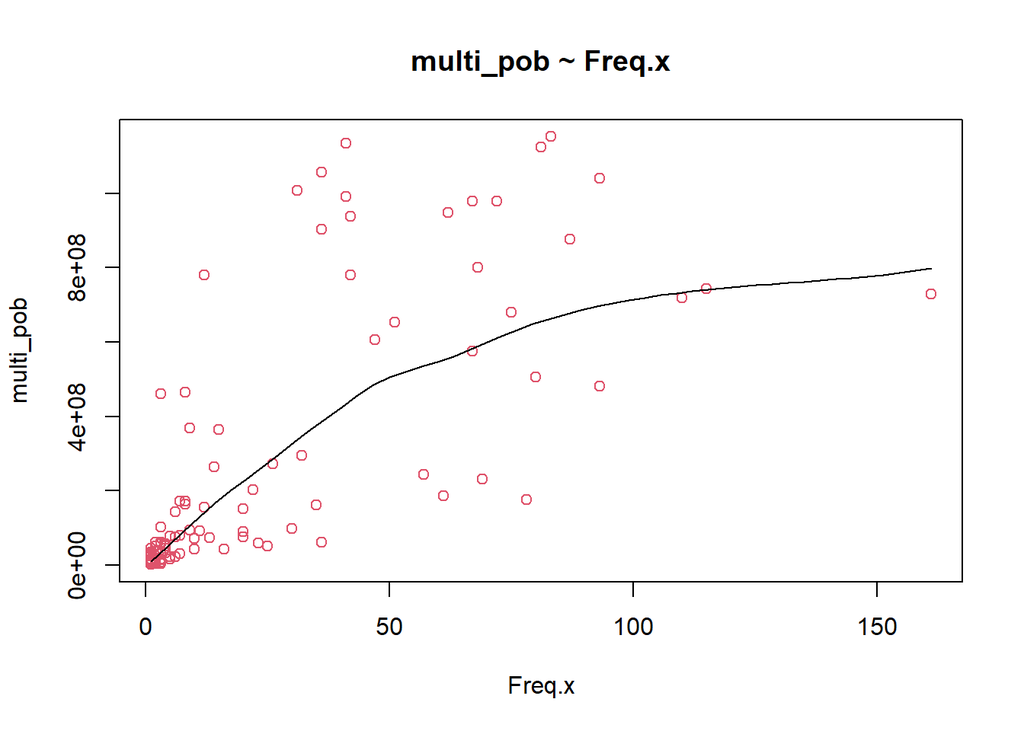

```r
scatter.smooth(x=h_y_m_comuna_corr_01$Freq.x, y=h_y_m_comuna_corr_01$multi_pob, main="multi_pob ~ Freq.x",
     xlab = "Freq.x",
     ylab = "multi_pob",
           col = 2)
```

### 7.2 Outliers

Hemos demostrado en el punto 5.7.2 de [aquí](https://rpubs.com/dataintelligence/expansion_viviendas_001) que la exclusión de ouliers no genera ninguna mejora en el modelo de regresión.

### 7.3 Modelo lineal

Aplicaremos un análisis de regresión lineal del ingreso expandido por zona sobre las frecuencias de respuestas zonales.

```r
linearMod <- lm( multi_pob~(Freq.x) , data=h_y_m_comuna_corr_01)
summary(linearMod)
```

```
##
## Call:
## lm(formula = multi_pob ~ (Freq.x), data = h_y_m_comuna_corr_01)
##
## Residuals:
##        Min         1Q     Median         3Q        Max
## -651509854  -69724042  -56531592   -5827010  739477894
##
## Coefficients:
##             Estimate Std. Error t value Pr(>|t|)
## (Intercept) 59152192   24815637   2.384   0.0187 *
## Freq.x       8209034     669460  12.262   <2e-16 ***
## ---
## Signif. codes:  0 '***' 0.001 '**' 0.01 '*' 0.05 '.' 0.1 ' ' 1
##
## Residual standard error: 226300000 on 120 degrees of freedom
##   (12 observations deleted due to missingness)
## Multiple R-squared:  0.5561, Adjusted R-squared:  0.5525
## F-statistic: 150.4 on 1 and 120 DF,  p-value: < 2.2e-16
```

### 7.4 Gráfica de la recta de regresión lineal

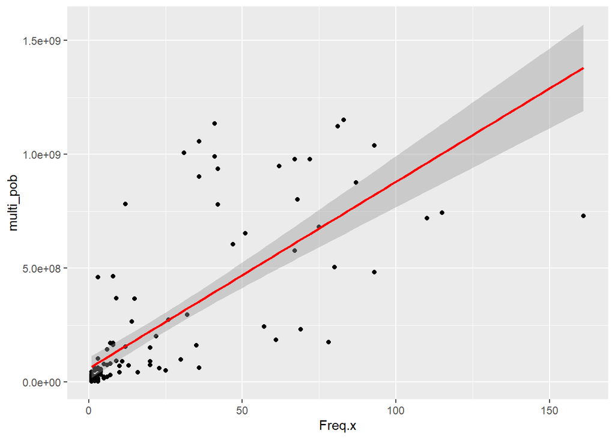

```r
ggplot(h_y_m_comuna_corr_01, aes(x = Freq.x , y = multi_pob)) +
  geom_point() +
  stat_smooth(method = "lm", col = "red")
```

## 8 Modelos alternativos

### 8.1 Modelo cuadrático

$$\hat Y = \beta_0 + \beta_1 X^2$$

```r
linearMod <- lm( multi_pob~(Freq.x^2) , data=h_y_m_comuna_corr_01)
summary(linearMod)
```

```
##
## Call:
## lm(formula = multi_pob ~ (Freq.x^2), data = h_y_m_comuna_corr_01)
##
## Residuals:
##        Min         1Q     Median         3Q        Max
## -651509854  -69724042  -56531592   -5827010  739477894
##
## Coefficients:
##             Estimate Std. Error t value Pr(>|t|)
## (Intercept) 59152192   24815637   2.384   0.0187 *
## Freq.x       8209034     669460  12.262   <2e-16 ***
## ---
## Signif. codes:  0 '***' 0.001 '**' 0.01 '*' 0.05 '.' 0.1 ' ' 1
##
## Residual standard error: 226300000 on 120 degrees of freedom
##   (12 observations deleted due to missingness)
## Multiple R-squared:  0.5561, Adjusted R-squared:  0.5525
## F-statistic: 150.4 on 1 and 120 DF,  p-value: < 2.2e-16
```

### 8.2 Modelo cúbico

$$\hat Y = \beta_0 + \beta_1 X^3$$

```r
linearMod <- lm( multi_pob~(Freq.x^3) , data=h_y_m_comuna_corr_01)
summary(linearMod)
```

```
##
## Call:
## lm(formula = multi_pob ~ (Freq.x^3), data = h_y_m_comuna_corr_01)
##
## Residuals:
##        Min         1Q     Median         3Q        Max
## -651509854  -69724042  -56531592   -5827010  739477894
##
## Coefficients:
##             Estimate Std. Error t value Pr(>|t|)
## (Intercept) 59152192   24815637   2.384   0.0187 *
## Freq.x       8209034     669460  12.262   <2e-16 ***
## ---
## Signif. codes:  0 '***' 0.001 '**' 0.01 '*' 0.05 '.' 0.1 ' ' 1
##
## Residual standard error: 226300000 on 120 degrees of freedom
##   (12 observations deleted due to missingness)
## Multiple R-squared:  0.5561, Adjusted R-squared:  0.5525
## F-statistic: 150.4 on 1 and 120 DF,  p-value: < 2.2e-16
```

### 8.3 Modelo logarítmico

$$\hat Y = \beta_0 + \beta_1 ln X$$

```r
linearMod <- lm( multi_pob~log(Freq.x) , data=h_y_m_comuna_corr_01)
summary(linearMod)
```

```
##
## Call:
## lm(formula = multi_pob ~ log(Freq.x), data = h_y_m_comuna_corr_01)
##
## Residuals:
##        Min         1Q     Median         3Q        Max
## -450947005 -117900754  -18067584   83416082  611725132
##
## Coefficients:
##              Estimate Std. Error t value Pr(>|t|)
## (Intercept) -68182944   30929282  -2.204   0.0294 *
## log(Freq.x) 159323227   12535054  12.710   <2e-16 ***
## ---
## Signif. codes:  0 '***' 0.001 '**' 0.01 '*' 0.05 '.' 0.1 ' ' 1
##
## Residual standard error: 221700000 on 120 degrees of freedom
##   (12 observations deleted due to missingness)
## Multiple R-squared:  0.5738, Adjusted R-squared:  0.5702
## F-statistic: 161.5 on 1 and 120 DF,  p-value: < 2.2e-16
```

### 8.4 Modelo exponencial

$$\hat Y = \beta_0 + \beta_1 e^X$$

No es aplicable sin una transformación pues los valores elevados a $e$ de Freq.x tienden a infinito.

### 8.5 Modelo con raíz cuadrada

$$\hat Y = \beta_0 + \beta_1 \sqrt {X}$$

```r
linearMod <- lm( multi_pob~sqrt(Freq.x) , data=h_y_m_comuna_corr_01)
summary(linearMod)
```

```
##
## Call:
## lm(formula = multi_pob ~ sqrt(Freq.x), data = h_y_m_comuna_corr_01)
##
## Residuals:
##        Min         1Q     Median         3Q        Max
## -541274423  -78148701   -3528161   18477712  641472905
##
## Coefficients:
##               Estimate Std. Error t value Pr(>|t|)
## (Intercept)  -93006102   29733374  -3.128  0.00221 **
## sqrt(Freq.x)  91632405    6501054  14.095  < 2e-16 ***
## ---
## Signif. codes:  0 '***' 0.001 '**' 0.01 '*' 0.05 '.' 0.1 ' ' 1
##
## Residual standard error: 208400000 on 120 degrees of freedom
##   (12 observations deleted due to missingness)
## Multiple R-squared:  0.6234, Adjusted R-squared:  0.6203
## F-statistic: 198.7 on 1 and 120 DF,  p-value: < 2.2e-16
```

### 8.6 Modelo raíz-raíz

$$\hat Y = {\beta_0}^2 + 2 \beta_0 \beta_1 \sqrt{X}+ \beta_1^2 X$$

```r
linearMod <- lm( sqrt(multi_pob)~sqrt(Freq.x) , data=h_y_m_comuna_corr_01)
summary(linearMod)
```

```
##
## Call:
## lm(formula = sqrt(multi_pob) ~ sqrt(Freq.x), data = h_y_m_comuna_corr_01)
##
## Residuals:
##      Min       1Q   Median       3Q      Max
## -13584.8  -2608.9   -903.5   1827.3  16718.1
##
## Coefficients:
##              Estimate Std. Error t value Pr(>|t|)
## (Intercept)    1163.3      777.1   1.497    0.137
## sqrt(Freq.x)   2904.3      169.9  17.092   <2e-16 ***
## ---
## Signif. codes:  0 '***' 0.001 '**' 0.01 '*' 0.05 '.' 0.1 ' ' 1
##
## Residual standard error: 5448 on 120 degrees of freedom
##   (12 observations deleted due to missingness)
## Multiple R-squared:  0.7088, Adjusted R-squared:  0.7064
## F-statistic: 292.2 on 1 and 120 DF,  p-value: < 2.2e-16
```

### 8.7 Modelo log-raíz

$$\hat Y = e^{\beta_0 + \beta_1 \sqrt{X}}$$

```r
linearMod <- lm( log(multi_pob)~sqrt(Freq.x) , data=h_y_m_comuna_corr_01)
summary(linearMod)
```

```
##
## Call:
## lm(formula = log(multi_pob) ~ sqrt(Freq.x), data = h_y_m_comuna_corr_01)
##
## Residuals:
##      Min       1Q   Median       3Q      Max
## -2.31438 -0.64062 -0.05497  0.72751  3.00989
##
## Coefficients:
##              Estimate Std. Error t value Pr(>|t|)
## (Intercept)  16.03421    0.15351  104.45   <2e-16 ***
## sqrt(Freq.x)  0.52190    0.03356   15.55   <2e-16 ***
## ---
## Signif. codes:  0 '***' 0.001 '**' 0.01 '*' 0.05 '.' 0.1 ' ' 1
##
## Residual standard error: 1.076 on 120 degrees of freedom
##   (12 observations deleted due to missingness)
## Multiple R-squared:  0.6683, Adjusted R-squared:  0.6655
## F-statistic: 241.8 on 1 and 120 DF,  p-value: < 2.2e-16
```

### 8.8 Modelo raíz-log

$$\hat Y = {\beta_0}^2 + 2 \beta_0 \beta_1 \ln{X}+ \beta_1^2 ln^2X$$

```r
linearMod <- lm( sqrt(multi_pob)~log(Freq.x) , data=h_y_m_comuna_corr_01)
summary(linearMod)
```

```
##
## Call:
## lm(formula = sqrt(multi_pob) ~ log(Freq.x), data = h_y_m_comuna_corr_01)
##
## Residuals:
##      Min       1Q   Median       3Q      Max
## -12511.6  -3299.4    167.5   2509.9  14126.5
##
## Coefficients:
##             Estimate Std. Error t value Pr(>|t|)
## (Intercept)   1558.3      761.7   2.046    0.043 *
## log(Freq.x)   5258.5      308.7  17.034   <2e-16 ***
## ---
## Signif. codes:  0 '***' 0.001 '**' 0.01 '*' 0.05 '.' 0.1 ' ' 1
##
## Residual standard error: 5461 on 120 degrees of freedom
##   (12 observations deleted due to missingness)
## Multiple R-squared:  0.7074, Adjusted R-squared:  0.705
## F-statistic: 290.2 on 1 and 120 DF,  p-value: < 2.2e-16
```

### 8.9 Modelo log-log

$$\hat Y = e^{\beta_0+\beta_1 ln{X}}$$

```r
linearMod <- lm( log(multi_pob)~log(Freq.x) , data=h_y_m_comuna_corr_01)
summary(linearMod)
```

```
##
## Call:
## lm(formula = log(multi_pob) ~ log(Freq.x), data = h_y_m_comuna_corr_01)
##
## Residuals:
##      Min       1Q   Median       3Q      Max
## -2.10835 -0.68027  0.02081  0.61873  2.85477
##
## Coefficients:
##             Estimate Std. Error t value Pr(>|t|)
## (Intercept) 15.98455    0.12746  125.41   <2e-16 ***
## log(Freq.x)  1.00922    0.05166   19.54   <2e-16 ***
## ---
## Signif. codes:  0 '***' 0.001 '**' 0.01 '*' 0.05 '.' 0.1 ' ' 1
##
## Residual standard error: 0.9138 on 120 degrees of freedom
##   (12 observations deleted due to missingness)
## Multiple R-squared:  0.7608, Adjusted R-squared:  0.7588
## F-statistic: 381.7 on 1 and 120 DF,  p-value: < 2.2e-16
```

## 9 Modelo log-log (**log-log**)

Es éste el modelo que nos entrega el mayor coeficiente de determinación de todos (0.7588).

### 9.1 Diagrama de dispersión sobre **log-log**

Desplegamos una curva suavizada por loess en el diagrama de dispersión.

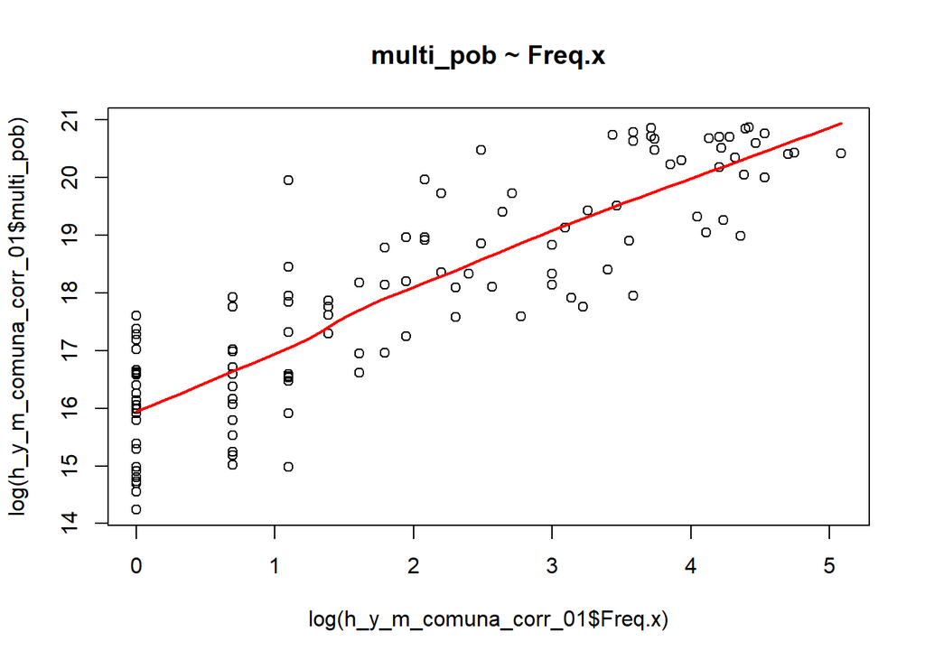

```r
scatter.smooth(x=log(h_y_m_comuna_corr_01$Freq.x), y=log(h_y_m_comuna_corr_01$multi_pob), lpars = list(col = "red", lwd = 2, lty = 1), main="multi_pob ~ Freq.x")
```

### 9.2 Modelo **log-log**

Observemos nuevamente el resultado sobre **log-log**.

```r
linearMod <- lm(log( multi_pob)~log(Freq.x) , data=h_y_m_comuna_corr_01)
summary(linearMod)
```

```
##
## Call:
## lm(formula = log(multi_pob) ~ log(Freq.x), data = h_y_m_comuna_corr_01)
##
## Residuals:
##      Min       1Q   Median       3Q      Max
## -2.10835 -0.68027  0.02081  0.61873  2.85477
##
## Coefficients:
##             Estimate Std. Error t value Pr(>|t|)
## (Intercept) 15.98455    0.12746  125.41   <2e-16 ***
## log(Freq.x)  1.00922    0.05166   19.54   <2e-16 ***
## ---
## Signif. codes:  0 '***' 0.001 '**' 0.01 '*' 0.05 '.' 0.1 ' ' 1
##
## Residual standard error: 0.9138 on 120 degrees of freedom
##   (12 observations deleted due to missingness)
## Multiple R-squared:  0.7608, Adjusted R-squared:  0.7588
## F-statistic: 381.7 on 1 and 120 DF,  p-value: < 2.2e-16
```

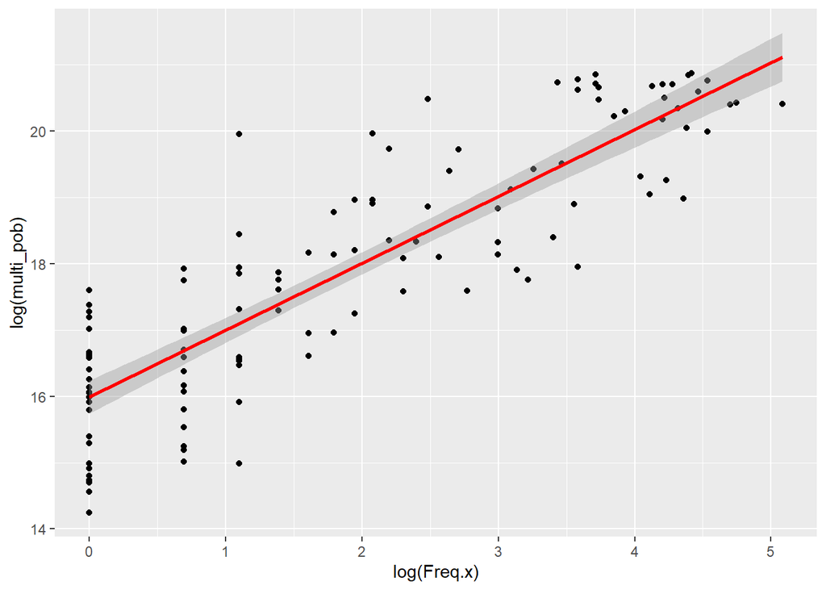

```r
ggplot(h_y_m_comuna_corr_01, aes(x = log(Freq.x) , y = log(multi_pob))) +
  geom_point() +
  stat_smooth(method = "lm", col = "red")
```

### 9.3 Análisis de residuos

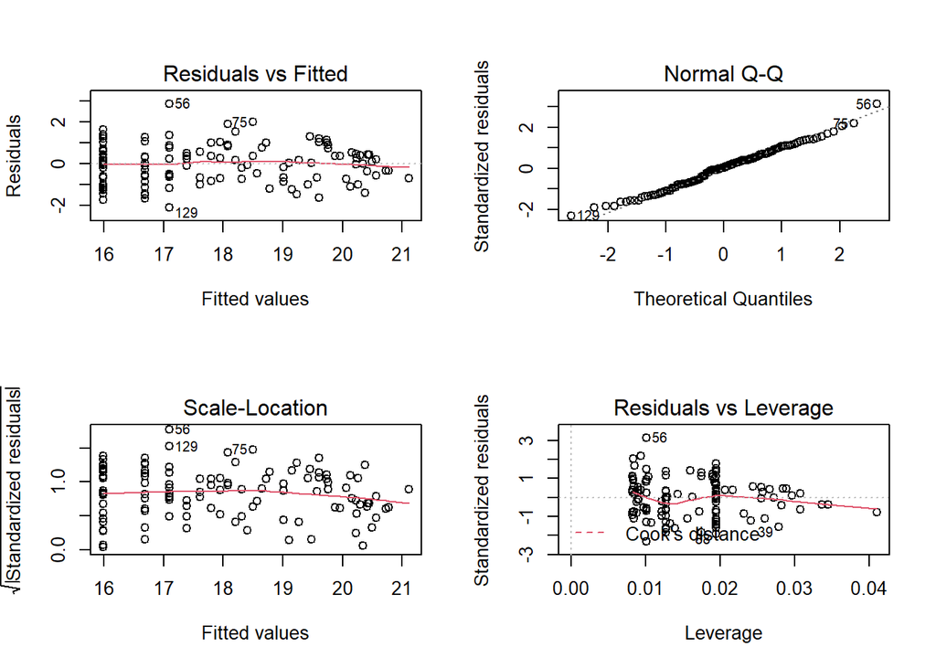

```r
par(mfrow = c (2,2))
plot(linearMod)
```

### 9.4 Ecuación del modelo

$$\hat Y = e^{15.98455+1.00922 \cdot ln{X}}$$

## 10 Aplicación la regresión a los valores de la variable a nivel de zona

Esta nueva variable se llamará: est_ing

```r
h_y_m_comuna_corr_01$est_ing <- exp(15.98455+1.00922 * log(h_y_m_comuna_corr_01$Freq.x))

r3_100 <- h_y_m_comuna_corr_01[c(1:100),]
kbl(r3_100) %>%
  kable_styling(bootstrap_options = c("striped", "hover")) %>%
  kable_paper() %>%
  scroll_box(width = "100%", height = "300px")
```

| zona | código.x | Freq.x | anio | comuna.x | promedio_i | año | comuna.y | personas | Ingresos_expandidos | Freq.y | p_poblacional | código.y | multi_pob | est_ing |
| --- | --- | --- | --- | --- | --- | --- | --- | --- | --- | --- | --- | --- | --- | --- |
| 11101011001 | 11101 | 30 | 2017 | Coyhaique | 302236.5 | 2017 | 11101 | 57818 | 17474712735 | 324 | 0.0056038 | 11101 | 97924642 | 270858316 |
| 11101011002 | 11101 | 80 | 2017 | Coyhaique | 302236.5 | 2017 | 11101 | 57818 | 17474712735 | 1672 | 0.0289183 | 11101 | 505339508 | 728850301 |
| 11101011003 | 11101 | 20 | 2017 | Coyhaique | 302236.5 | 2017 | 11101 | 57818 | 17474712735 | 499 | 0.0086305 | 11101 | 150816037 | 179898422 |
| 11101011004 | 11101 | 22 | 2017 | Coyhaique | 302236.5 | 2017 | 11101 | 57818 | 17474712735 | 667 | 0.0115362 | 11101 | 201591778 | 198062236 |
| 11101011005 | 11101 | 32 | 2017 | Coyhaique | 302236.5 | 2017 | 11101 | 57818 | 17474712735 | 977 | 0.0168979 | 11101 | 295285107 | 289087506 |
| 11101011006 | 11101 | 93 | 2017 | Coyhaique | 302236.5 | 2017 | 11101 | 57818 | 17474712735 | 1595 | 0.0275866 | 11101 | 482067294 | 848465567 |
| 11101011007 | 11101 | 75 | 2017 | Coyhaique | 302236.5 | 2017 | 11101 | 57818 | 17474712735 | 2251 | 0.0389325 | 11101 | 680334470 | 682890685 |
| 11101022003 | 11101 | 2 | 2017 | Coyhaique | 302236.5 | 2017 | 11101 | 57818 | 17474712735 | 11 | 0.0001903 | 11101 | 3324602 | 17611946 |
| 11101022010 | 11101 | 2 | 2017 | Coyhaique | 302236.5 | 2017 | 11101 | 57818 | 17474712735 | 53 | 0.0009167 | 11101 | 16018537 | 17611946 |
| 11101022031 | 11101 | 1 | 2017 | Coyhaique | 302236.5 | 2017 | 11101 | 57818 | 17474712735 | 55 | 0.0009513 | 11101 | 16623010 | 8749875 |
| 11101022038 | 11101 | 3 | 2017 | Coyhaique | 302236.5 | 2017 | 11101 | 57818 | 17474712735 | 339 | 0.0058632 | 11101 | 102458190 | 26516865 |
| 11101032005 | 11101 | 1 | 2017 | Coyhaique | 302236.5 | 2017 | 11101 | 57818 | 17474712735 | 53 | 0.0009167 | 11101 | 16018537 | 8749875 |
| 11101032032 | 11101 | 5 | 2017 | Coyhaique | 302236.5 | 2017 | 11101 | 57818 | 17474712735 | 257 | 0.0044450 | 11101 | 77674793 | 44403415 |
| 11101032034 | 11101 | 1 | 2017 | Coyhaique | 302236.5 | 2017 | 11101 | 57818 | 17474712735 | 31 | 0.0005362 | 11101 | 9369333 | 8749875 |
| 11101032901 | 11101 | 2 | 2017 | Coyhaique | 302236.5 | 2017 | 11101 | 57818 | 17474712735 | 43 | 0.0007437 | 11101 | 12996172 | 17611946 |
| 11101042022 | 11101 | 3 | 2017 | Coyhaique | 302236.5 | 2017 | 11101 | 57818 | 17474712735 | 27 | 0.0004670 | 11101 | 8160387 | 26516865 |
| 11101042024 | 11101 | 3 | 2017 | Coyhaique | 302236.5 | 2017 | 11101 | 57818 | 17474712735 | 47 | 0.0008129 | 11101 | 14205118 | 26516865 |
| 11101042027 | 11101 | 6 | 2017 | Coyhaique | 302236.5 | 2017 | 11101 | 57818 | 17474712735 | 77 | 0.0013318 | 11101 | 23272214 | 53373744 |
| 11101052004 | 11101 | 6 | 2017 | Coyhaique | 302236.5 | 2017 | 11101 | 57818 | 17474712735 | 474 | 0.0081981 | 11101 | 143260124 | 53373744 |
| 11101052008 | 11101 | 5 | 2017 | Coyhaique | 302236.5 | 2017 | 11101 | 57818 | 17474712735 | 76 | 0.0013145 | 11101 | 22969978 | 44403415 |
| 11101052014 | 11101 | 6 | 2017 | Coyhaique | 302236.5 | 2017 | 11101 | 57818 | 17474712735 | 250 | 0.0043239 | 11101 | 75559137 | 53373744 |
| 11101052901 | 11101 | 3 | 2017 | Coyhaique | 302236.5 | 2017 | 11101 | 57818 | 17474712735 | 50 | 0.0008648 | 11101 | 15111827 | 26516865 |
| 11101062023 | 11101 | 1 | 2017 | Coyhaique | 302236.5 | 2017 | 11101 | 57818 | 17474712735 | 54 | 0.0009340 | 11101 | 16320774 | 8749875 |
| 11101062025 | 11101 | 2 | 2017 | Coyhaique | 302236.5 | 2017 | 11101 | 57818 | 17474712735 | 24 | 0.0004151 | 11101 | 7253677 | 17611946 |
| 11101072014 | 11101 | 4 | 2017 | Coyhaique | 302236.5 | 2017 | 11101 | 57818 | 17474712735 | 107 | 0.0018506 | 11101 | 32339311 | 35449723 |
| 11101072018 | 11101 | 57 | 2017 | Coyhaique | 302236.5 | 2017 | 11101 | 57818 | 17474712735 | 806 | 0.0139403 | 11101 | 243602658 | 517685359 |
| 11101072019 | 11101 | 7 | 2017 | Coyhaique | 302236.5 | 2017 | 11101 | 57818 | 17474712735 | 102 | 0.0017642 | 11101 | 30828128 | 62357932 |
| 11101072020 | 11101 | 4 | 2017 | Coyhaique | 302236.5 | 2017 | 11101 | 57818 | 17474712735 | 190 | 0.0032862 | 11101 | 57424944 | 35449723 |
| 11101072035 | 11101 | 3 | 2017 | Coyhaique | 302236.5 | 2017 | 11101 | 57818 | 17474712735 | 109 | 0.0018852 | 11101 | 32943784 | 26516865 |
| 11101072036 | 11101 | 8 | 2017 | Coyhaique | 302236.5 | 2017 | 11101 | 57818 | 17474712735 | 539 | 0.0093224 | 11101 | 162905499 | 71354002 |

[output cut: 70 more lines]

## 11 División del valor estimado entre la población total de la zona para obtener el ingreso medio por zona

$$Ingreso \_ Medio\_zona = est\_ing / (personas * p\_poblacional)$$

```r
h_y_m_comuna_corr_01$ing_medio_zona <- h_y_m_comuna_corr_01$est_ing  /( h_y_m_comuna_corr_01$personas  * h_y_m_comuna_corr_01$p_poblacional)

r3_100 <- h_y_m_comuna_corr_01[c(1:100),]
kbl(r3_100) %>%
  kable_styling(bootstrap_options = c("striped", "hover")) %>%
  kable_paper() %>%
  scroll_box(width = "100%", height = "300px")
```

| zona | código.x | Freq.x | anio | comuna.x | promedio_i | año | comuna.y | personas | Ingresos_expandidos | Freq.y | p_poblacional | código.y | multi_pob | est_ing | ing_medio_zona |
| --- | --- | --- | --- | --- | --- | --- | --- | --- | --- | --- | --- | --- | --- | --- | --- |
| 11101011001 | 11101 | 30 | 2017 | Coyhaique | 302236.5 | 2017 | 11101 | 57818 | 17474712735 | 324 | 0.0056038 | 11101 | 97924642 | 270858316 | 835982.46 |
| 11101011002 | 11101 | 80 | 2017 | Coyhaique | 302236.5 | 2017 | 11101 | 57818 | 17474712735 | 1672 | 0.0289183 | 11101 | 505339508 | 728850301 | 435915.25 |
| 11101011003 | 11101 | 20 | 2017 | Coyhaique | 302236.5 | 2017 | 11101 | 57818 | 17474712735 | 499 | 0.0086305 | 11101 | 150816037 | 179898422 | 360517.88 |
| 11101011004 | 11101 | 22 | 2017 | Coyhaique | 302236.5 | 2017 | 11101 | 57818 | 17474712735 | 667 | 0.0115362 | 11101 | 201591778 | 198062236 | 296944.88 |
| 11101011005 | 11101 | 32 | 2017 | Coyhaique | 302236.5 | 2017 | 11101 | 57818 | 17474712735 | 977 | 0.0168979 | 11101 | 295285107 | 289087506 | 295893.05 |
| 11101011006 | 11101 | 93 | 2017 | Coyhaique | 302236.5 | 2017 | 11101 | 57818 | 17474712735 | 1595 | 0.0275866 | 11101 | 482067294 | 848465567 | 531953.33 |
| 11101011007 | 11101 | 75 | 2017 | Coyhaique | 302236.5 | 2017 | 11101 | 57818 | 17474712735 | 2251 | 0.0389325 | 11101 | 680334470 | 682890685 | 303372.14 |
| 11101022003 | 11101 | 2 | 2017 | Coyhaique | 302236.5 | 2017 | 11101 | 57818 | 17474712735 | 11 | 0.0001903 | 11101 | 3324602 | 17611946 | 1601086.03 |
| 11101022010 | 11101 | 2 | 2017 | Coyhaique | 302236.5 | 2017 | 11101 | 57818 | 17474712735 | 53 | 0.0009167 | 11101 | 16018537 | 17611946 | 332300.87 |
| 11101022031 | 11101 | 1 | 2017 | Coyhaique | 302236.5 | 2017 | 11101 | 57818 | 17474712735 | 55 | 0.0009513 | 11101 | 16623010 | 8749875 | 159088.64 |
| 11101022038 | 11101 | 3 | 2017 | Coyhaique | 302236.5 | 2017 | 11101 | 57818 | 17474712735 | 339 | 0.0058632 | 11101 | 102458190 | 26516865 | 78220.84 |
| 11101032005 | 11101 | 1 | 2017 | Coyhaique | 302236.5 | 2017 | 11101 | 57818 | 17474712735 | 53 | 0.0009167 | 11101 | 16018537 | 8749875 | 165091.99 |
| 11101032032 | 11101 | 5 | 2017 | Coyhaique | 302236.5 | 2017 | 11101 | 57818 | 17474712735 | 257 | 0.0044450 | 11101 | 77674793 | 44403415 | 172775.93 |
| 11101032034 | 11101 | 1 | 2017 | Coyhaique | 302236.5 | 2017 | 11101 | 57818 | 17474712735 | 31 | 0.0005362 | 11101 | 9369333 | 8749875 | 282254.04 |
| 11101032901 | 11101 | 2 | 2017 | Coyhaique | 302236.5 | 2017 | 11101 | 57818 | 17474712735 | 43 | 0.0007437 | 11101 | 12996172 | 17611946 | 409580.15 |
| 11101042022 | 11101 | 3 | 2017 | Coyhaique | 302236.5 | 2017 | 11101 | 57818 | 17474712735 | 27 | 0.0004670 | 11101 | 8160387 | 26516865 | 982106.10 |
| 11101042024 | 11101 | 3 | 2017 | Coyhaique | 302236.5 | 2017 | 11101 | 57818 | 17474712735 | 47 | 0.0008129 | 11101 | 14205118 | 26516865 | 564188.61 |
| 11101042027 | 11101 | 6 | 2017 | Coyhaique | 302236.5 | 2017 | 11101 | 57818 | 17474712735 | 77 | 0.0013318 | 11101 | 23272214 | 53373744 | 693165.50 |
| 11101052004 | 11101 | 6 | 2017 | Coyhaique | 302236.5 | 2017 | 11101 | 57818 | 17474712735 | 474 | 0.0081981 | 11101 | 143260124 | 53373744 | 112602.83 |
| 11101052008 | 11101 | 5 | 2017 | Coyhaique | 302236.5 | 2017 | 11101 | 57818 | 17474712735 | 76 | 0.0013145 | 11101 | 22969978 | 44403415 | 584255.46 |
| 11101052014 | 11101 | 6 | 2017 | Coyhaique | 302236.5 | 2017 | 11101 | 57818 | 17474712735 | 250 | 0.0043239 | 11101 | 75559137 | 53373744 | 213494.97 |
| 11101052901 | 11101 | 3 | 2017 | Coyhaique | 302236.5 | 2017 | 11101 | 57818 | 17474712735 | 50 | 0.0008648 | 11101 | 15111827 | 26516865 | 530337.29 |
| 11101062023 | 11101 | 1 | 2017 | Coyhaique | 302236.5 | 2017 | 11101 | 57818 | 17474712735 | 54 | 0.0009340 | 11101 | 16320774 | 8749875 | 162034.73 |
| 11101062025 | 11101 | 2 | 2017 | Coyhaique | 302236.5 | 2017 | 11101 | 57818 | 17474712735 | 24 | 0.0004151 | 11101 | 7253677 | 17611946 | 733831.10 |
| 11101072014 | 11101 | 4 | 2017 | Coyhaique | 302236.5 | 2017 | 11101 | 57818 | 17474712735 | 107 | 0.0018506 | 11101 | 32339311 | 35449723 | 331305.82 |
| 11101072018 | 11101 | 57 | 2017 | Coyhaique | 302236.5 | 2017 | 11101 | 57818 | 17474712735 | 806 | 0.0139403 | 11101 | 243602658 | 517685359 | 642289.53 |
| 11101072019 | 11101 | 7 | 2017 | Coyhaique | 302236.5 | 2017 | 11101 | 57818 | 17474712735 | 102 | 0.0017642 | 11101 | 30828128 | 62357932 | 611352.28 |
| 11101072020 | 11101 | 4 | 2017 | Coyhaique | 302236.5 | 2017 | 11101 | 57818 | 17474712735 | 190 | 0.0032862 | 11101 | 57424944 | 35449723 | 186577.49 |
| 11101072035 | 11101 | 3 | 2017 | Coyhaique | 302236.5 | 2017 | 11101 | 57818 | 17474712735 | 109 | 0.0018852 | 11101 | 32943784 | 26516865 | 243273.99 |
| 11101072036 | 11101 | 8 | 2017 | Coyhaique | 302236.5 | 2017 | 11101 | 57818 | 17474712735 | 539 | 0.0093224 | 11101 | 162905499 | 71354002 | 132382.19 |

[output cut: 70 more lines]

Guardamos:

```r
saveRDS(h_y_m_comuna_corr_01, "casen_censo_region_11.rds")
```

## 12 Referencias

https://rpubs.com/osoramirez/316691

https://dataintelligencechile.shinyapps.io/casenfinal

Manual_de_usuario_Censo_2017_16R.pdf

http://www.censo2017.cl/microdatos/

Censo de Población y Vivienda

https://www.ine.cl/estadisticas/sociales/censos-de-poblacion-y-vivienda/poblacion-y-vivienda

http://r-statistics.co/Linear-Regression.html